# Lab 2

Advanced Data Visualization

```r
library(tidyverse)
library(readxl)
library(here)
library(scales)
library(ggrepel)
library(gganimate)
library(gifski)
library(leaflet)
library(geojsonio)
library(sf)
library(viridisLite)
```

# Instructions

**Create a Quarto file for ALL Lab 2 (no separate files for Parts 1 and 2).**

- Make sure your final file is carefully formatted, so that each analysis is clear and concise.
- Be sure your knitted `.html` file shows **all** your source code, including any function definitions.

# Part One: Identifying Bad Visualizations

If you happen to be bored and looking for a sensible chuckle, you should check out these [Bad Visualisations](https://badvisualisations.tumblr.com/). Looking through these is also a good exercise in cataloging what makes a visualization good or bad.

## Dissecting a Bad Visualization

Below is an example of a less-than-ideal visualization from the collection linked above. It comes to us from data provided for the [Wellcome Global Monitor 2018 report](https://wellcome.ac.uk/reports/wellcome-global-monitor/2018) by the Gallup World Poll:

[figure not shown]

1. While there are certainly issues with this image, do your best to tell the story of this graph in words. That is, what is this graph telling you? What do you think the authors meant to convey with it?

The graph is telling me the amount of trust in vaccines that different countries have, with each country belonging to a specific global region. The general trend is that the global regions are ordered from highest trust to lowest trust from top to bottom (Asia, Middle East and North Africa, etc.). The authors likely meant to show the general trend in vaccine trust among countries within their respective global regions. The authors also wanted to highlight particular countries (typically the lower/higher trust ones within a particular global region) by providing their labels.

2. List the variables that appear to be displayed in this visualization. *Hint: Variables refer to columns in the data.*

The variables are global region, country, and % of people who believe vaccines are safe. The y-axis on this graph appears to act as a way to separate the countries (which is a bit strange) and doesn’t have a particular variable attached to it.

3. Now that you’re versed in the grammar of graphics (e.g., `ggplot`), list the *aesthetics* used and which *variables* are mapped to each.

The x-axis aesthetic is mapped to the variable % of people who believe vaccines are safe. The y-axis aesthetic technically isn’t mapped to anything, but the countries are separated across the y-axis. Another aesthetic is the separation of the plot into 7 regions (using group perhaps?), with the global region variable mapped to it.

4. What type of graph would you call this? Meaning, what `geom` would you use to produce this plot?

I would use geom_point to produce this plot. This is a dot graph/point graph.

5. Provide at least four problems or changes that would improve this graph. *Please format your changes as bullet points!*
- Remove the legend on the bottom of the graph, as it isn’t needed due to the color separation and text already present
- I would add a label for the median bars to indicate the value of the median for each global region
- If only some of the data points are going to be labeled, there needs to be a line connecting the point to the name, because sometimes it is quite hard to tell which label is associated with which dot
- I would consider separating each global region out into frames in a gif. That way, if it isn’t too crowded, each country could be labeled separately, and there would not be as much information to take in all at once

## Improving the Bad Visualization

The data for the Wellcome Global Monitor 2018 report can be downloaded at the following site: [https://wellcome.ac.uk/reports/wellcome-global-monitor/2018](https://wellcome.org/sites/default/files/wgm2018-dataset-crosstabs-all-countries.xlsx)

There are two worksheets in the downloaded dataset file. You may need to read them in separately, but you may also just use one if it suffices.

```r
crosstabs <- read_excel(here("wgm2018.xlsx"), sheet=1, skip=2)
full_data <- read_excel(here("wgm2018.xlsx"), sheet=2)
dictionary <- read_excel(here("wgm2018.xlsx"), sheet=3)
#this is cleaned data for q1 specifically
cleaned <- read.csv(here("wgm_cleaned.csv"))
```

This appends country codes and region codes onto the cleaned dataset

```r
# Remove the trailing comma
text <- sub(",$", "", dictionary[1,3])

# Split by comma
parts <- strsplit(text, ",\\s*")[[1]]

parts <- as_tibble(parts)

country_codes <- separate_wider_delim(parts, value, delim = "=", names = c("code", "country"))

cleaned_codes <- left_join(cleaned, country_codes, by = "country")

countries_regions <- full_data %>%
  select(WP5, Regions_Report) %>%
  rename("code" = "WP5") %>%
  mutate(code = as.character(code))

clean_regions <- left_join(cleaned_codes, countries_regions, by = "code") %>%
  distinct()
```

This gets the proportion in each country who said “Strongly agree” or “Somewhat agree”

```r
grouped <- clean_regions %>%
  group_by(country) %>%
  mutate(pct_vaccines_safe = sum(National.results[answer %in% c("Strongly agree", "Somewhat agree")]) / 1) %>%
  select(country, pct_vaccines_safe, Regions_Report) %>%
  distinct() %>%
  mutate(Region = case_when(
    Regions_Report %in% c(1, 2, 4, 5) ~ "Africa",
    Regions_Report %in% c(6, 7, 8) ~ "Americas",
    Regions_Report %in% c(9, 10, 11, 12, 18) ~ "Asia",
    Regions_Report %in% c(3, 13) ~ "Middle East and North Africa",
    Regions_Report %in% c(15, 16, 17, 0) ~ "Europe",
    Regions_Report == 14 ~ "Former Soviet Union"
  )) %>%
  select(-Regions_Report) %>%
  filter(!is.na(Region))
```

6. Improve the visualization above by either re-creating it with the issues you identified fixed OR by creating a new visualization that you believe tells the same story better.

Get top 5 and bottom 5 countries for each region, and get medians for each region

```r
top5bot5 <- grouped %>%
    group_by(Region) %>%
    mutate(rank = rank(pct_vaccines_safe)) %>%
    filter(rank <= 5 | rank > n() - 5) %>%
    ungroup()

medians <- grouped %>%
        group_by(Region) %>%
        summarize(median_value = median(pct_vaccines_safe)) %>%
        mutate(y = Inf, label = paste0(scales::percent(median_value, accuracy = 0.1)))
```

```r
label_data <- grouped %>%
  group_by(Region) %>%
  slice_max(pct_vaccines_safe, n = 1) %>%
  ungroup()
```

Create the visualization

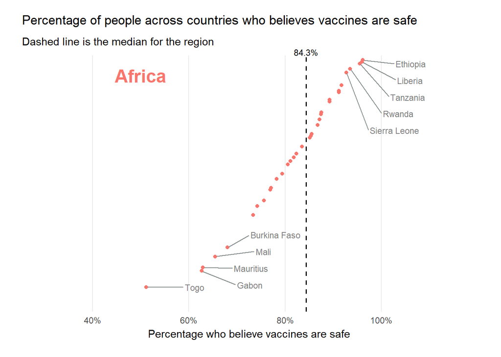

```r
test <- grouped %>%
  ggplot(aes(x = pct_vaccines_safe, y=reorder(country, pct_vaccines_safe))) +
  geom_vline(
    data = medians,
    aes(xintercept = median_value),
    linetype = "dashed",
    color = "black",
    linewidth = 0.7
  ) +
  geom_point(aes(color = Region), show.legend = FALSE) +
  geom_text_repel(data = top5bot5,
                  aes(x = pct_vaccines_safe, y = country, label=country),
                  size = 3,
                  nudge_x = 0.1,
                  nudge_y = -0.1,
                  direction = "y",
                  segment.color = "azure4",
                  color = "gray50",
                  box.padding = 0.35,
                  max.overlaps = 20,
                  max.time =    3,
    ) +
  geom_text(
    data = medians,
    aes(x = median_value, y = y, label = label),
    vjust = 0,
    hjust = 0.5,
    size = 3,
    color = "black"
  ) +
  geom_text(
    data = label_data,
    aes(x = 0.5, y = Inf, label = Region, color = Region),
    vjust = 2,
    size = 6.5,
    fontface = "bold",
    show.legend = FALSE,
    inherit.aes = FALSE
  ) +
  theme_minimal() +
  theme(
    strip.text = element_text(face = "bold", size = 10),
    panel.grid.minor.x = element_blank(),
    axis.text.y= element_blank(),
    axis.ticks.y = element_blank(),
    panel.spacing = unit(1, "lines"),
    panel.grid.major.y = element_blank(),
    panel.grid.minor.y = element_blank(),
    plot.margin = margin(15, 25, 15, 15)
  ) +
  labs(
    title = "Percentage of people across countries who believes vaccines are safe",
    subtitle = "Dashed line is the median for the region",
    x = "Percentage who believe vaccines are safe",
    y = ""
  ) +
  scale_x_continuous(labels = percent_format(scale=100),
                     breaks = seq(0.4, 1, by = 0.2),
                     expand = expansion(mult = c(0.05, 0.15))) +
                     coord_cartesian(clip = "off") +
                     transition_states(Region, transition_length = 0, state_length = 10)

animate(test, nframes = 60, duration = 30)
```

The country labels slightly jitter and get in the way a tad but this is the best I was able to come up with based off my initial ideas

# Part Two: Broad Visualization Improvement

The full Wellcome Global Monitor 2018 report can be found here: https://wellcome.ac.uk/sites/default/files/wellcome-global-monitor-2018.pdf. Surprisingly, the visualization above does not appear in the report despite the citation in the bottom corner of the image!

## Second Data Visualization Improvement

**For this second plot, you must select a plot that uses maps so you can demonstrate your proficiency with the `leaflet` package!**

7. Select a data visualization in the report that you think could be improved. Be sure to cite both the page number and figure title. Do your best to tell the story of this graph in words. That is, what is this graph telling you? What do you think the authors meant to convey with it?

I am looking at page 55, Chart 3.3: Map of countries according to levels of Trust in Scientists.

The graph is attempting to portray the level of trust in science across the various world countries.

8. List the variables that appear to be displayed in this visualization.

The variables displayed are country, and Wellcome Global Monitor Trust in Scientists Index (recoded into 3 categories). As to what particular category is plotted per country, I am a bit unsure, but I think it is the “high trust in science” category.

9. Now that you’re versed in the grammar of graphics (ggplot), list the aesthetics used and which variables are specified for each.

This isn’t a graph like I am used to, so I’m going to assume something like color = % of population who have high trust in science, and group = country?

10. What type of graph would you call this?

This is a choropleth map.

11. List all of the problems or things you would improve about this graph.
- The title and subtitle are confusing. How are three different categories being represented at once here? Are the shadings just the majority category level of trust of each country? Then that means these shouldn’t be a percentage?
- The legend is misleading, but this is tied into the issue with the title.
- What I think the best thing to do would be to just display one category for each country. So each country would be shaded according to their % of people who have “high trust” in science. This would make the message less confusing.
12. Improve the visualization above by either re-creating it with the issues you identified fixed OR by creating a new visualization that you believe tells the same story better.

Get high trust in scientists % by country

```r
q2data <- crosstabs %>%
fill(Question, .direction="down") %>%
  filter(Question == "Wellcome Global Monitor Trust in Scientists Index (recoded into 3 categories)", Response == "High trust") %>%
  mutate(`Column N %...4` = round(`Column N %...4`,4)) %>%
  rename(`High trust in scientists %` = `Column N %...4`) %>%
  select(1,4)
```

I went through by hand to double-check country name consistencies between the data from the WGM and the country geojson data.

```r
q2data$Country[q2data$Country == "United States"] <- "United States of America"
q2data$Country[q2data$Country == "Congo, Rep."] <- "Republic of the Congo"
q2data$Country[q2data$Country == "Tanzania"] <- "United Republic of Tanzania"
```

Make the leaflet map

```r
# Load GeoJSON
WorldCountry <- st_read(here("countries.geo.json"))
#join q2data and drop na's
WorldCountry <-WorldCountry %>%
  left_join(q2data, by = c("name" = "Country")) %>%
  drop_na()

# Define color palette
pal <- colorBin("Greens", domain = WorldCountry$`High trust in scientists %`, bins = 6, na.color = "lightgrey")

# Create map
leaflet(WorldCountry) %>%
  addTiles() %>%
  addPolygons(
    fillColor = ~pal(`High trust in scientists %`),
    color = "white",
    weight = 1,
    fillOpacity = 0.8,
    highlight = highlightOptions(
      weight = 2,
      color = "darkgrey",
      fillOpacity = 1,
      bringToFront = TRUE
    ),
    label = ~paste0(name, ": ", 100*`High trust in scientists %`, "%")
  ) %>%
  addLegend(
    pal = pal,
    values = ~WorldCountry$`High trust in scientists %`,
    title = "Proportion with High Trust in Scientists",
    position = "bottomright"
  )
```

[interactive chart not shown]

## Third Data Visualization Improvement

**For this third plot, you must use one of the other `ggplot2` extension packages mentioned this week (e.g., `gganimate`, `plotly`, `patchwork`, `cowplot`).**

13. Select a data visualization in the report that you think could be improved. Be sure to cite both the page number and figure title. Do your best to tell the story of this graph in words. That is, what is this graph telling you? What do you think the authors meant to convey with it?

I am selecting Chart 5.3: Perceived effectiveness of vaccines by region. It is on page 111.

The graph is attempting to show how different regions of the world view vaccine effectiveness with a horizontal stacked bar chart. They intend to showcase different world region views on vaccine effectiveness.

14. List the variables that appear to be displayed in this visualization.

Region, opinion on vaccine effectiveness (6 categories)

15. Now that you’re versed in the grammar of graphics (ggplot), list the aesthetics used and which variables are specified for each.

The x-axis is just a 0 to 1 axis, the y-axis is the region of the world, and the color is the category of belief in vaccine effectiveness.

16. What type of graph would you call this?

This is a stacked bar chart, so I would use geom_bar() most likely.

17. List all of the problems or things you would improve about this graph.
- In my opinion, the graph is a bit overcrowded due to the stacked bar chart nature
- Labelling is inconsistent due to some segments being very small
- My idea is to separate the graph into a gif where each frame is a different world region and it shows just a regular bar chart. This would also eliminate the need for a legend.
18. Improve the visualization above by either re-creating it with the issues you identified fixed OR by creating a new visualization that you believe tells the same story better.

Get data for q3

```r
q3data <- crosstabs %>%
  fill(Question, .direction="down") %>%
  filter(Question == "Q26 Do you strongly or somewhat agree, strongly or somewhat disagree or neither agree nor disagree with the following statement? Vaccines are effective.") %>%
  rename(`Proportion` = `Column N %...4`) %>%
  select(1, 3:5)
```

Similar to q1, append region and country codes to the data

```r
# Remove the trailing comma
text <- sub(",$", "", dictionary[1,3])

# Split by comma
parts <- strsplit(text, ",\\s*")[[1]]

parts <- as_tibble(parts)

country_codes <- separate_wider_delim(parts, value, delim = "=", names = c("code", "Country"))

cleaned_codes <- left_join(q3data, country_codes, by = "Country")

countries_regions <- full_data %>%
  select(WP5, Regions_Report) %>%
  rename("code" = "WP5") %>%
  mutate(code = as.character(code),
         Regions_Report = as.character(Regions_Report))

clean_regions <- left_join(cleaned_codes, countries_regions, by = "code") %>%
  distinct()
```

Convert region code to region name and clean data a bit more

```r
# Remove the trailing comma
text <- sub(",$", "", dictionary[57,3])

# Split by comma
parts <- strsplit(text, ",\\s*")[[1]]

parts <- as_tibble(parts)

region_codes <- separate_wider_delim(parts, value, delim = "=", names = c("Regions_Report", "Region"))

cleaned_codes <- left_join(clean_regions, region_codes, by = "Regions_Report")

q3clean <- cleaned_codes %>%
  mutate(Region = replace_na(Region, "Not assigned")) %>%
  select(-c(Proportion,code,Regions_Report)) %>%
  filter(Response != "Total") %>%
  rename(Counts = `Unweighted Count...5`)
```

Going to use the raw counts to make the bar graphs since averaging proportions across countries doesn’t make sense, and the weight adjustment they used for the proportions is unclear to me

Calculate proportions from raw counts for each region

```r
region_response_props <- q3clean %>%
  group_by(Region, Response) %>%
  summarise(RegionCounts = sum(Counts)) %>%
  mutate(Proportion = RegionCounts / sum(RegionCounts))

region_response_props <- region_response_props %>%
   mutate(Response = factor(Response, levels = c(
    "Strongly agree",
    "Somewhat agree",
    "Neither agree nor disagree",
    "Somewhat disagree",
    "Strongly disagree",
    "Don't know/Refused"
  )))
```

Make a df with each region once to grab labels

```r
label_data <- region_response_props %>%
  group_by(Region) %>%
  slice_max(RegionCounts, n = 1) %>%
  ungroup()
```

Create visualization

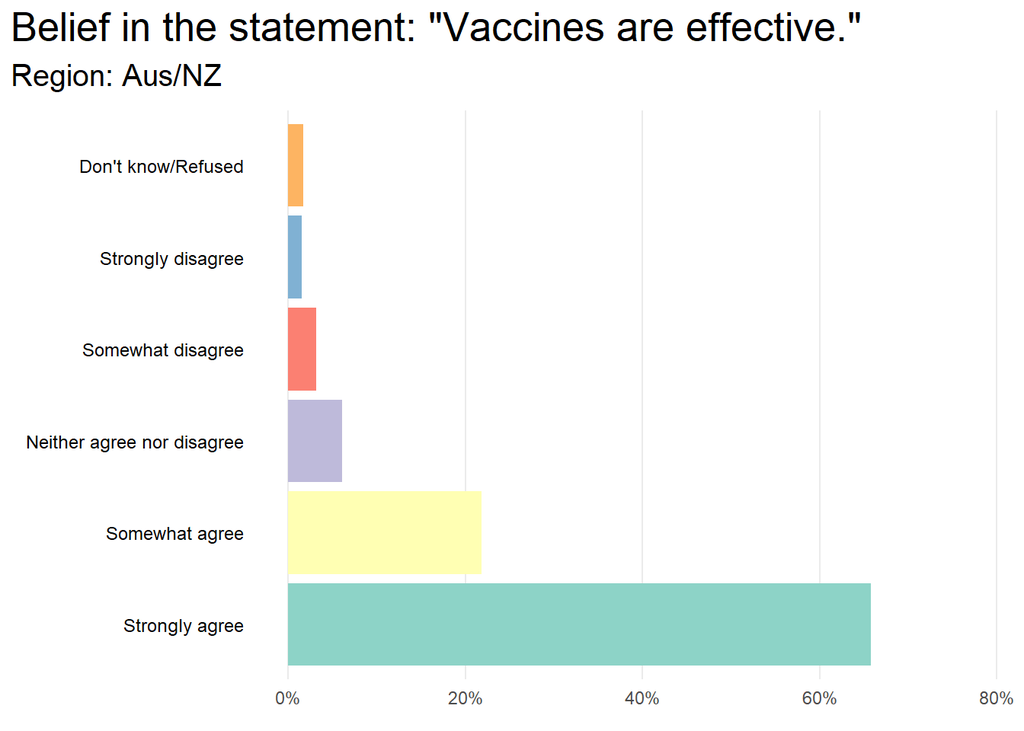

```r
p <- ggplot(region_response_props, aes(x = factor(Response, c(
    "Strongly agree",
    "Somewhat agree",
    "Neither agree nor disagree",
    "Somewhat disagree",
    "Strongly disagree",
    "Don't know/Refused")), y = Proportion, fill = Response)) +
     geom_col() +
  # geom_text(aes(label = scales::percent(Proportion, accuracy = 1), group=Response),
  #         hjust = -0.1,
  #         size = 4,
  #         color = "black",
  #         fontface = "bold") +
     scale_fill_brewer(palette = "Set3") +
     labs(title = "Belief in the statement: \"Vaccines are effective.\"", subtitle = "Region: {closest_state}",
       x = "", y = "") +
     scale_y_continuous(labels = scales::percent_format()) +
     coord_flip() +
     theme_minimal() +
     theme(legend.position = "none",
        panel.grid.major.y = element_blank(),
        panel.grid.minor.x = element_blank(),
        plot.title.position = "plot",
        plot.title = element_text(size = 20, hjust = 0),
        plot.subtitle = element_text(size = 15, hjust = 0, face="bold"),
        axis.text.y = element_text(size = 9,, color = "black")) +
     transition_states(Region, transition_length = 4, state_length = 2) +
     ease_aes('cubic-in-out')

animate(p, fps = 10, duration = 50)
```